# 자연언어처리 7주차_기계학습을 사용한 자연언어처리 #1: 기계학습(machine learning) 개관

고려대학교 일반대학원 심리학과

2022년 10월 17일 월요일 6-7교시

# 1. 기계학습 유형 개관

## (1) 지도학습(supervised learning)

- 정의: **예측모형(predictive models)**을 생성하는 알고리즘.
  - 예측모형: 예측변수(predictors)/특성변수(features)를 사용하여 결과변수(outcome)/목표변수(target)를 예측하는 과제에 사용되는 모형.
  - 예측 모델링(predictive modeling): 정확한 예측을 하기 위한 수학적 도구 또는 모형을 개발하는 과정.
  - 학습 알고리즘: 예측모형의 학습 알고리즘은 목표변수와 예측변수간의 관계를 발견하고 모델링하는 과정.
  - 지도(supervision): 알고리즘에게 목표변수의 값을 제공함으로써 무엇을 학습해야 하는지를 알려주는 것을 가리킴. 따라서 목표변수 값에 비추어볼 때 알고리즘이 학습과정 동안 최적의 매개변수를 제대로 찾아가고 있는지 감독할 수 있음.
- 예시
  - 고객의 특성을 활용하여 고객이 향후 6주간 서비스 제공자를 바꿀 확률 예측하기.
  - 집의 특성을 활용하여 집 판매가격 예측하기.
  - 피고용자의 특성을 활용하여 퇴사확률 예측하기.
  - 환자의 특성과 증상을 활용하여 재입원할 확률 예측하기.
  - 제품의 특성을 활용하여 판매시점 예측하기.
  - 문서의 특성을 활용하여 저자의 성별 예측하기.
  - 문서의 특성을 활용하여 문서의 감성(긍정/부정) 예측하기.
  - 음절연쇄를 구성하는 음절의 특성을 활용하여 단어/비단어 여부 예측하기.
  - 주변 단어들의 특성을 활용하여 해당 단어의 품사/문장성분 예측하기.
- 종류
  - 회귀(regression).
  - 분류(classification).

### 1) 회귀문제

- 정의: **수치화된 결과(연속변수)**를 예측하는 것이 목적인 지도학습 유형.
- 예시
  - 집의 특성을 활용하여 집 판매가격 예측하기. [EX] 건축연도와 평수의 조합을 통해 집의 판매가격 예측.
  - 제품의 특성을 활용하여 판매시점 예측하기.

**[그림 1] 회귀문제 예시**

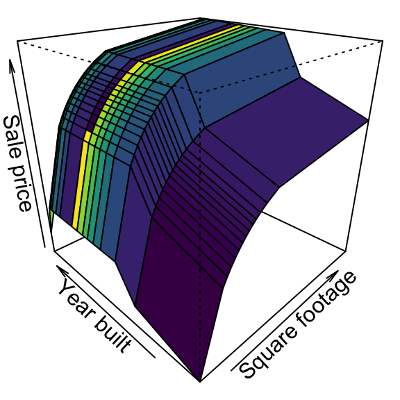

### 2) 분류문제

**[그림 2] 분류문제 예시**

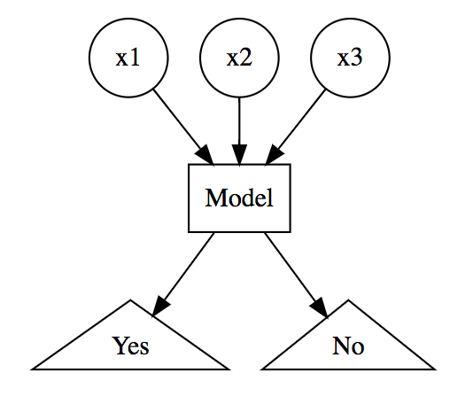

## (2) 비지도학습(unsupervised learning)

- 정의
  - **목표변수가 없이** 분석을 수행하는 알고리즘.
  - 주어진 데이터를 더 잘 이해하고 기술하는 데 목표를 둠.
  - 데이터에 존재하는 서로 다른 집단들을 분별하는 용도로 사용됨.
- 특징
  - 고전적 선형회귀모형은 예측변수 간 상관이 높을 경우 문제가 될 수 있음. 그러나 차원축소 기법을 사용하면 서로 무관한 소수의 예측변수들만 남길 수 있음. $\rightarrow$ 이렇게 남겨진 소수의 예측변수들을 지도학습 모형에 투입하는 것도 가능.
  - 목표변수의 예측과 무관한 탐색적 자료 분석(exploratory data analysis, EDA)의 목적으로도 사용.
  - 학습결과의 질을 평가하기 어려움
    - 지도학습: 우리의 모형이 모형 적합화(fitting)에 사용되지 않은 목표변수 값들을 얼마나 잘 예측하고 있는지를 점검할 수 있음.
    - 비지도학습: 목표변수가 존재하지 않으므로 모형의 예측력을 점검할 방법이 없음.

### 1) 군집화(clustering)

- 목표: 예측변수를 바탕으로 관찰값들을 유사한 집단끼리 분류하는 것.
- 예시
  - 고객들을 유사한 특성을 지닌 집단으로 나누기.
  - 논문들을 유사한 특성을 지닌 집단으로 나누기.

### 2) 차원축소(dimension reduction)

- 목표
  - 예측변수들의 수를 줄임으로써 최소한의 주요 예측변수들로 집단을 구분.
  - 규모가 큰 데이터의 구조를 탐색하고 단순화하는 데 사용.
  - 최대 2-3차원의 영역에서 집단 간의 관계성을 발견하는 데 목적을 둠.
- 예시
  - 고객들을 여러 개의 동질집단으로 나누기. $\rightarrow$ 해당 결과를 고객유형별 맞춤형 마케팅 전략을 수립하는 데 사용 가능.
  - 유사한 탐색 및 구매 이력을 지닌 온라인 쇼핑몰 고객들끼리 묶어내기. $\rightarrow$ 유사한 구매이력을 바탕으로 개별 고객에게 특화된 제품 추천.
  - 유사한 구매행동을 나타내는 제품군 파악하기. $\rightarrow$ 담당자가 이들을 제품군별로 관리할 수 있도록 함.
  - 유사한 특성을 나타내는 음절군/음소군 파악하기. $\rightarrow$ 같은 음절군/음소군 내 음절/음소들의 공통점과 다른 음절군/음소군 간의 차이점을 구체적으로 파악함으로 하위언어 단위에 대한 지식 고양.

**[그림 3] 차원축소 예시(복잡한 차원$\rightarrow$단순한 차원)**

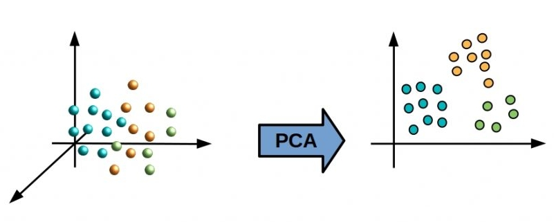

## (3) **기계학습을 사용한 자연언어처리** 개관

### 1) 모형구축 과정

- 특성변수 선처리하기(feature engineering).
- 데이터 분절하기(data splitting).
- 모형 타당도 검증 및 초매개변수 조정(model validation & hyperparameter tuning).
- 모형 수행의 질 측정하기(performance measurement).

### 2) 지도학습 기법

- 회귀
  - 선형회귀(linear regression).
  - 로지스틱 회귀(logistic regression).
  - 규제 회귀(regularized regression): 과적합 방지를 위한 제한장치들([EX] lasso penalty, ridge penalty)을 장착한 일반화 선형회귀(generalized linear regression models)의 일종.
- 분류
  - *k*-최근접 이웃(*k*-nearest neighbors).
  - 결정 나무(decision trees).
  - 랜덤 포레스트(random forests).
  - 서포트 벡터 머신(support vector machine).
  - 모형 쌓기(stacked models): 메타 알고리즘이 여러 개별 알고리즘의 예측을 조합하여 최종 예측 수행. 개별 알고리즘보다 높은 수준의 수행을 나타냄.

### 3) 비지도학습 기법

- 차원축소
  - 주성분 분석(principal component analysis, PCA).
  - 일반화 저순위 모형(generalized low rank models, GLRMs).
- 군집화
  - *k*-평균 군집화(*k*-means clustering).
  - 위계적 군집화(hierachical clustering).
  - 모형 기반 군집화(model-based clustering).

# References

Boehmke, B., & Greenwell, B. (2020). *Hands-On machine learning with R*. Retrieved July 17, 2022 from https://bradleyboehmke.github.io/HOML/